# 第4回 人間の代役をコードで作る

経済プログラミング特論II

第4回

人間の代役をコードで作る

合っても、正しいとは限らない

経済プログラミング特論II

第4回 — Topic01

エージェント・ベース・モデル

一人のルールを、関数に書く

## 前回の振り返り

前回のポイント — 第3回「美人投票を開けて読む」

行動ルールとは何だったか

何を見て、何を選ぶかの決まり  
「前回の平均の 2/3」を、手で1回だけ当てた

今日は、そのルールを計算機に何回も当てる

## 今日の道のり

1

ルールを書く

演習 1-1・1-2

半分と追随

2

ルールで比べる

演習 2

教室の R1 から

3

混ぜる

演習 3

固定人数と固定点

4

確かめる

演習 4

合う2組のその先

一人のルールを書けば、集団の動きが計算できる  
ただし、合うことと正しいことは別

## 3 つの行動ルールの箱 見た平均 60

前に出てきた 3 つの行動ルール。入力は、自分の数 50 と見た平均 60

[figure not shown]

固定・追随・一定倍。3つの行動ルール

## エージェント・ベース・モデル

用語

**ABM**＝一人ずつのルールから、集団の結果を計算で作る方法

**正式名**＝エージェント・ベース・モデル（エービーエム）

- **エージェント**：決める一人。AI でなくてよい
- **状態**：その人がいま書いている数
- **行動ルール**：次の数の決め方（固定・追随・一定倍）

3つのルールを関数にし、40人に何回も選ばせる

## ABM の部品：Python の3つの道具

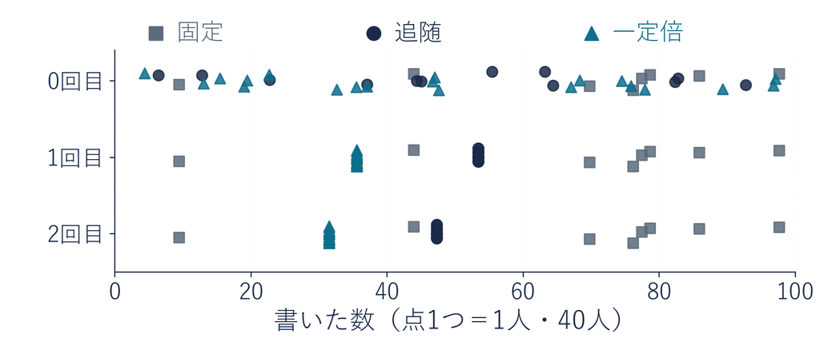

関数＝ルール・リスト＝集団・ループ＝回

## 教室で映した平均 43.38 と 3 つの箱

2026年度のデータ

今度は教室の数。R1 の後に映した平均 43.38 を、同じ 3 つの箱に入れる

[figure not shown]

**箱の中身はそのまま。入力を替えるだけで、出力が出る**

## ルールの関数化

```python
def fixed(own, prev_mean):         # 固定：自分の最初の数を書き続ける
    return own
def follow(own, prev_mean):        # 追随：前回の平均をそのまま書く
    return prev_mean
def multiply(own, prev_mean):      # 一定倍：前回の平均の 2/3 を書く
    return prev_mean * 2 / 3

print(fixed(50, 60), follow(50, 60), multiply(50, 60))
print(fixed(50, 43.38), follow(50, 43.38), multiply(50, 43.38))
```

| 行 | 部品 | 渡すもの | 返ってくるもの（return） |
| --- | --- | --- | --- |
| 1-2 | **① 固定** | own（その人の最初の数）と prev_mean | own のまま |
| 3-4 | **② 追随** | 同じ 2 つ | prev_mean（前回の平均） |
| 5-6 | **③ 一定倍** | 同じ 2 つ | prev_mean の 2/3 |
| 8-9 | **④ 試す** | 50 と 60・50 と 43.38 | 箱の図と同じ 3 つの数 |

`def 名前(入力):` ＝ 関数を作る（3つとも入力の形が同じ）

## ルールの関数の写経と実行

1. **＋ コード**で空の  
   セルを足す
2. p.9 の 9 行を上から写す
3. **▶** か **Shift + Enter** で実行  
   （Mac は Shift + return）
4. 2 行の出力が  
   箱の図と同じ数かを見る

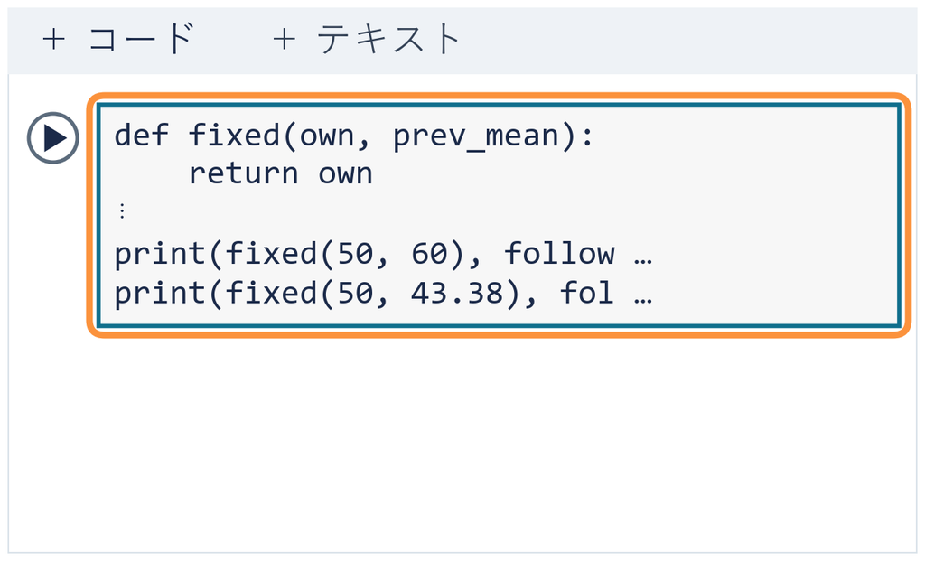

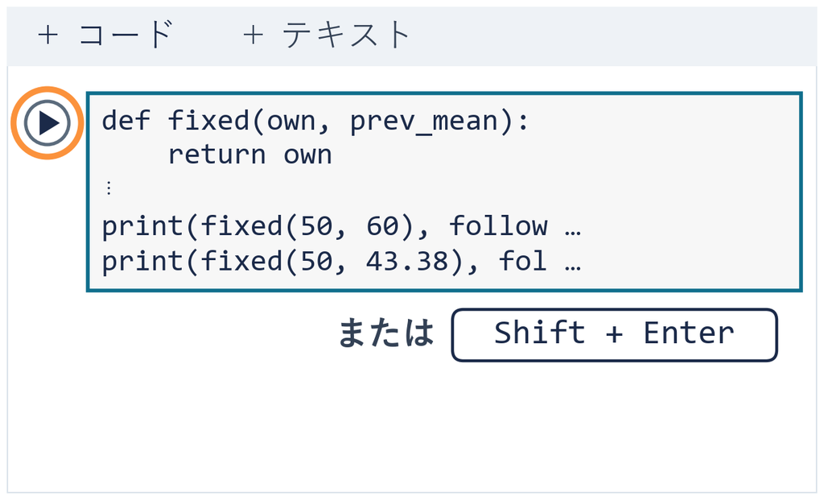

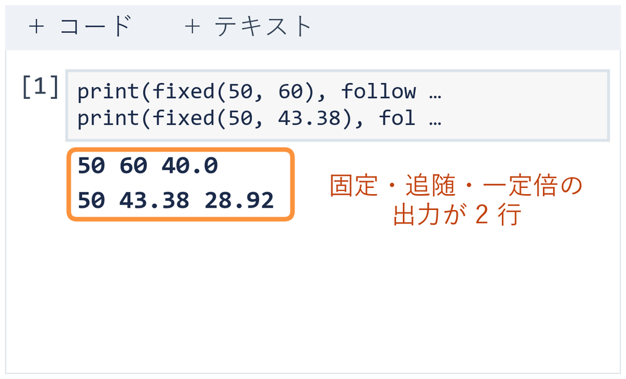

⏸ PAUSE 動画を止めて $3$ 分。2 行が出たら再生に戻る

## 演習 1-1 半分を書くルール

p.10 の出力 50 60 40.0 ／ 50 43.38 28.92

演習 1-1

前回の平均の半分を書くルール half を作る

```python
def half(own, prev_mean):          # 半分：前回の平均の半分を書く
    return prev_mean * 2 / 3       # ← ここを書き換える
print(half(50, 43.38))
```

1. **写す**：新しいセルに、上の 3 行をそのまま写す
2. **書き換える**：2 行目の `2 / 3` を `1 / 2` に
3. **終わり**：21.69 が出たら（28.92 なら書き換え忘れ）

own ＝ その人の最初の数。half では使わないが、4 つとも入力の形をそろえるために受け取る

⏸ PAUSE 動画を止めて $3$ 分。数が出たら再生に戻る

## 演習 1-1 の答え

2 行目を `return prev_mean * 1 / 2` にすると 21.69

入力

$43.38$

一定倍と同じ見た平均

書き換え前

$43.38 \times 2 \div 3$

$= 28.92$

2/3 のまま（一定倍と同じ）

書き換え後

$43.38 \times 1 \div 2$

$= 21.69$

1/2 を掛ける

変えたのは return の 1 行だけ。名前と入力の形は、ほかの 3 つの関数と同じ

## 更新の 2 つの方法

更新の方法は 2 種類。違うのは、平均をいつ出すか

同時更新

全員が同じ前回の平均を見て  
一斉に書く

逐次更新

1人書くたびに  
平均を出し直す

- **この授業は同時更新**：教室の R2 も全員が同じ平均を見た
- **コードでは**：ループの前に prev_mean を1回だけ決める

どちらを使うかは、再現したい実験の状況で選ぶ

## 2 つの更新で動かす一定倍の 5 人

具体例：2 つの更新で、5 人（全員一定倍）を 1 回動かすと

[figure not shown]

同時更新は全員 33.33（最初の平均 50 の 2/3）  
逐次更新は1人書くたびに平均が変わり、ばらばらになる

## 40人の最初の数のリスト

```python
import numpy as np
import matplotlib.pyplot as plt
import pandas as pd

seed = 42                          # 初期集団の出発点（スライドと同じ 42）
first = np.random.default_rng(seed).uniform(0, 100, 40)  # 40人の最初の数
print("40人の平均:", round(np.mean(first), 2),
      " 標準偏差:", round(np.std(first), 2))
```

- **first**：40人の最初の数のリスト（0〜100）
- **seed**：乱数の出発点。42 なら毎回同じ40人
- **出力**：40人の平均: 53.36 ・標準偏差: 28.56

`uniform(0, 100, 40)` ＝ 0〜100 の数を、どれも同じくらい出やすく40個引く

## 最初の40人の散らばり

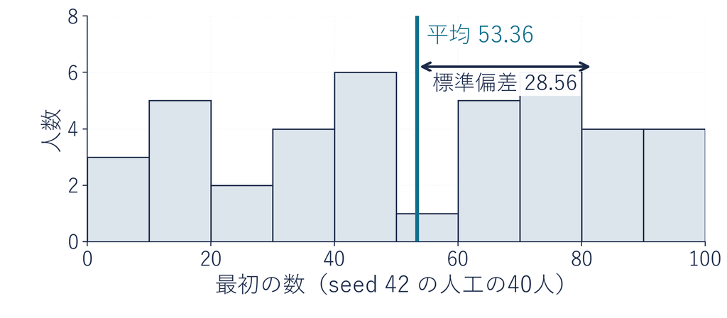

0〜100 に広く散らばった40人から出発する

## 関数を並べたリスト

```python
rules = [fixed, follow, multiply]  # 関数を3つ並べたリスト
print(rules[2](80, 60))            # 番号2の関数 multiply に 80 と 60 を渡す
rules = [fixed] * 40               # fixed を40個並べる（40人とも固定）
```

- **rules[2]**：リストの番号2（0 から数える）＝ multiply
- **`rules[2](80, 60)`**：own＝80、prev_mean＝60 を渡す → 60 の 2/3 で 40.0
- **[fixed] * 40**：i 番目の関数が、i 番目の人のルール

リストの i 番目が、i 番目の人のルール

## ループで書く1回の更新

```python
def step(x, rules):
    prev_mean = np.mean(x)         # 先に「前回の平均」を1つだけ決める
    new = []
    for i in range(len(x)):        # 40人が1人ずつ、同じ prev_mean を見る
        new.append(rules[i](first[i], prev_mean))
    return np.array(new)
```

- **x**：前回の40人が書いた数（リスト）
- **rules**：40人ぶんのルール関数のリスト
- **new**：今回の40人の数。1人ずつ append し  
  最後に np.array（numpy の数の並び）にする

`rules[i](first[i], prev_mean)` ＝ i 番目の人のルールに  
その人の最初の数 first[i] と前回の平均を渡す（固定の人は最初の数を書き続ける）

## 関数のリストと step の写経と実行

1. **＋ コード**でセルを足し  
   p.17 のリスト 3 行を写す
2. **▶** か **Shift + Enter** で  
   実行し、`40.0` を見る
3. もう 1 つセルを足し  
   p.18 の 6 行を写して実行
4. step のセルは出力なし  
   それで step ができた

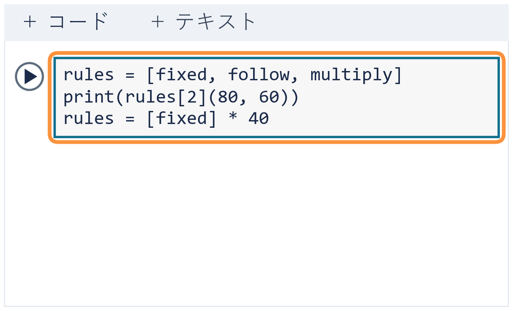

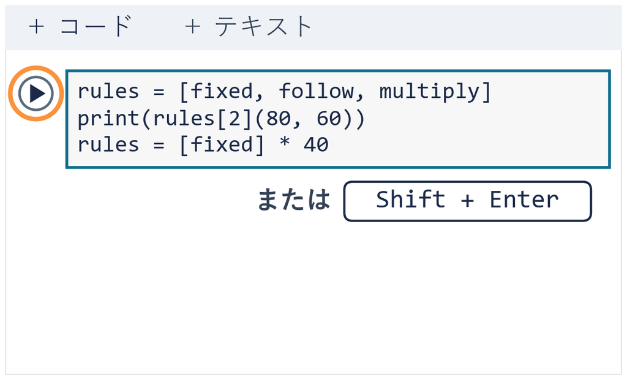

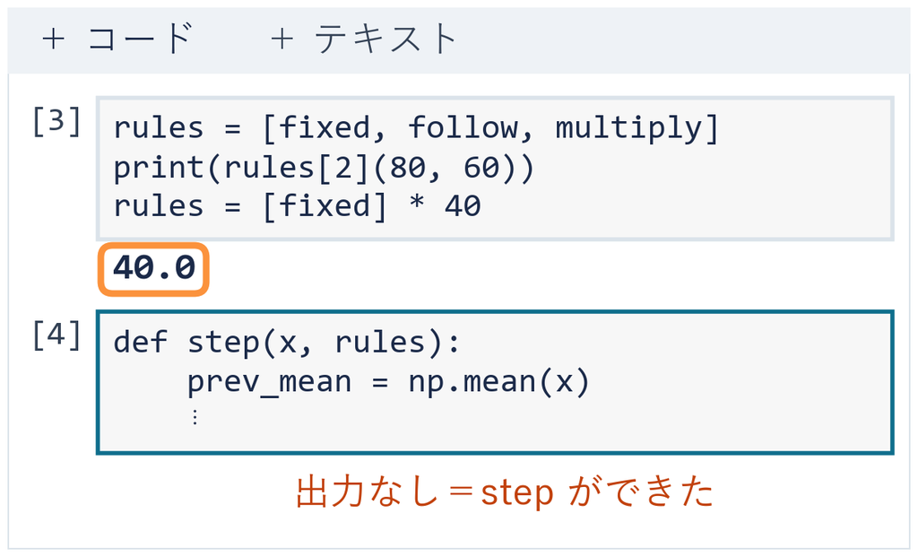

⏸ PAUSE 動画を止めて $3$ 分。2 つのセルを実行したら再生に戻る

## 使える場面：SNS の乗り換え

p.19 の出力 リスト 40.0 ／ step は出力なし

追随の人

友だちの多くが  
移ったら  
自分も新しい  
アプリへ移る

固定の人

周りが移っても  
今のアプリを  
使い続ける

誰が何を見るかを書けば、広がり方が計算できる

## 演習 1-2 固定から追随への書き換え

```python
rules = [fixed] * 40               # ← fixed を follow に書き換える
x1 = step(first, rules)
print("前の平均:", round(np.mean(first), 2),
      " 1回後の平均:", round(np.mean(x1), 2))
print("最初の3人:", np.round(first[:3], 2), "→", np.round(x1[:3], 2))
```

1. 小課題ノートの**段1**の、ルール・40人・リスト・step の 4 セルを  
   上から順に実行しておく
2. 新しいセルに 5 行を写して実行し  
   fixed を follow に変えて、もう一度実行する
3. 前後の平均と、最初の3人の数を書き留める

`[fixed] * 40` ＝ fixed を40個並べたリスト（40人とも固定）・`round(x, 2)` ＝ 小数第2位まで

⏸ PAUSE 動画を止めて5分。2回ぶんの出力を書いたら再生に戻る

## 演習 1-2 の答え：動かない平均

固定：前の平均: 53.36 1回後の平均: 53.36  
最初の3人: [77.4 43.89 85.86] → [77.4 43.89 85.86]  
追随：前の平均: 53.36 1回後の平均: 53.36  
最初の3人: [77.4 43.89 85.86] → [53.36 53.36 53.36]

- **平均**：固定でも追随でも 53.36 のまま
- **一人ずつ**：固定はそのまま、追随は3人とも 53.36

関数の名前1つで、40人の動きが変わる

## 追随で1回：1点に集まる40人

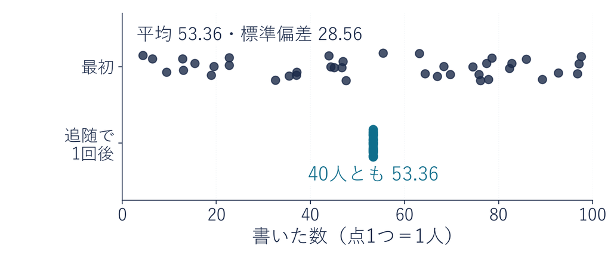

平均は同じ 53.36 でも、散らばりは消えた

## まとめ

- **ABM**：一人ひとりのルールから、集団の結果を計算で作る
- **3つの道具**：関数・リスト・ループ
- **同時更新**：全員が同じ前回の平均を見る  
  （再現したい実験の状況から選んだ更新）

次は、この更新を何回も回して、ルールどうしを比べる

経済プログラミング特論II

第4回 — Topic02

集団動学と統制した比較

同じ出発点で、ルールだけを変える

## 今日の道のり

1

ルールを書く

演習 1-1・1-2

半分と追随

2

ルールで比べる

演習 2

教室の R1 から

3

混ぜる

演習 3

固定人数と固定点

4

確かめる

演習 4

合う2組のその先

同じ出発点から、ルールだけを変えて何回も回す

## 標準偏差：散らばりを表す1つの数

用語（前に出てきたもの）

**標準偏差**＝平均からのずれの、だいたいの大きさ

- **最初の40人**：標準偏差 28.56（0〜100 に広く散らばる）
- **全員が同じ数**：どの人もずれが0なので、標準偏差も0
- **Python**：np.std(x) で出る

今日は、平均と標準偏差を回ごとに並べて見る

計算のしかた：ずれを2乗して平均し、√（ルート）をとる

## 集団動学と統制した比較

用語

**集団動学**＝回を追った、平均と散らばりの動き

**統制した比較**＝出発点は共通、ルールだけ変える

- **出発点**：seed 42 の40人（どのルールも同じ）
- **変えるもの**：ルールだけ（固定・追随・一定倍）
- **変えないもの**：人数40・回数・最初の数

3つのルールを、同じ40人で10回ずつ回す

## 一度に1つだけ変える比較

計算機の中なら、比べる相手を自分で作れる

✕ ルールと出発点を同時に変える

一定倍は seed 1 の40人、  
追随は seed 42 の40人  
→ 行き先の違いが、  
どちらのせいか言えない

○ ルールだけを変える

3つとも seed 42 の同じ40人  
→ 違いが出たら、  
ルールのせいと言える

変えるのは、一度に1つだけ

## 固定と追随の平均の動き

同じ40人を、全員固定と全員追随で10回ずつ動かす

- **①** 固定のほうが、平均が大きく動く
- **②** 追随のほうが、平均が大きく動く
- **③** どちらも平均は動かない

動画を止めて1分。①〜③から1つ選び、理由を考える

## 5人を3回動かす表

同じ5人（10・30・50・70・90）から、ルールだけ変えて3回

[figure not shown]

固定と追随は平均 50 のまま。一定倍は 50 → 33.33 → 22.22 → 14.81

## 10回動かした平均

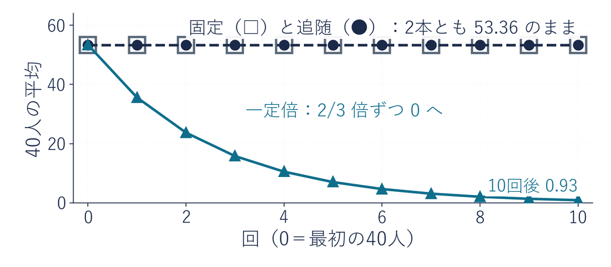

答えは③。固定も追随も 53.36 のまま

## 同じ平均の違う中身

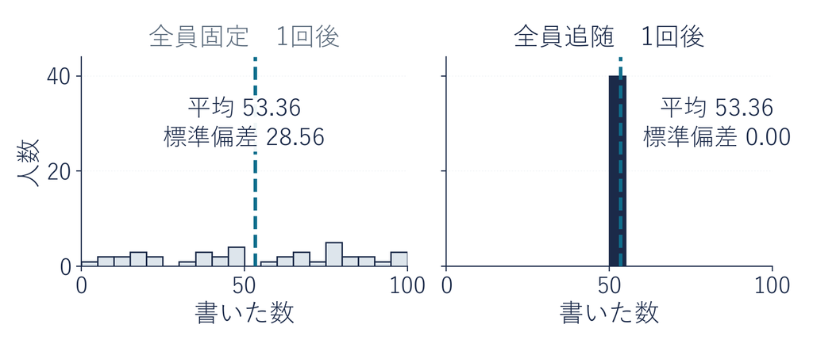

平均は同じ 53.36、標準偏差は 28.56 と 0

## 標準偏差の経路

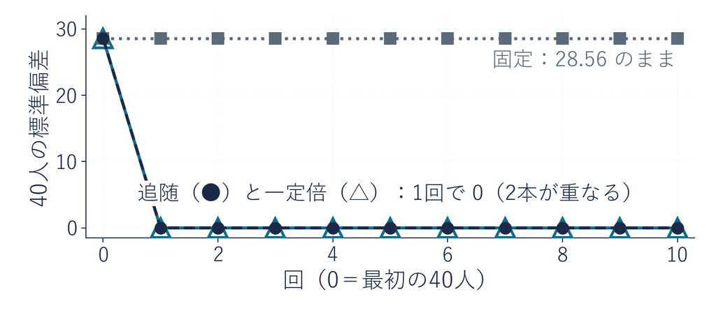

平均の線だけでは、固定と追随を見分けられない

## 「必ず0へ行く」という読み違い

✕ よくある読み違い

計算機で何回も回せば  
全員が 0 を書く  
理論の答えへ必ず行く

○ 図で見たこと

固定と追随は  
10回回しても 53.36  
0へ向かったのは  
一定倍だけ

行き先を決めるのは、与えたルールの形

## デモ：計算機の中の40人

数の話

同じ集団（40人か、教室の R1 の52人）から出発し、  
ルールの組だけを変えて1回ずつ同時に更新する

- **何を見るか**：▶ を押すたびに、平均と散らばりがどう動くか
- **図の意味**：左＝今の集団のヒストグラム／右＝回ごとの平均と標準偏差  
  （教室のときは R2 の平均 34.58 の点線）
- **操作**：タブでルールの組を選ぶ・スライダで人数を決める・▶ で1回

ミッション 平均は同じで中身が違う2つのタブを探す  
（ほかのタブは後で使う）

※ 次のスライドへ進むときは、デモの枠の外を一度クリックしてから ← → キーを押す

[interactive chart not shown]

## 何回も回す関数

```python
def simulate(rules, rounds=10):
    x = first
    means, sds = [np.mean(x)], [np.std(x)]
    for t in range(rounds):        # 1回ずつ、全員を同時に更新する
        x = step(x, rules)
        means.append(np.mean(x))
        sds.append(np.std(x))
    return means, sds
```

- **x = first**：どのルールも同じ40人から出発
- **means・sds**：回ごとの平均と標準偏差をためる
- **rounds**：回す回数。書かなければ10回

`for t in range(rounds):` ＝ 0〜9 を1つずつ t に渡す（10回くり返す）・`step` はトピック1で書いた関数

## 3つのルールの10回の比較の写経

```python
paths = {}
for name, rules in [("固定", [fixed] * 40), ("追随", [follow] * 40),
                    ("一定倍", [multiply] * 40)]:
    means, sds = simulate(rules)   # 出発点はどれも同じ first
    paths[name] = (means, sds)
    print(name, " 平均:", round(means[0], 2), "→", round(means[1], 2),
          "→", round(means[2], 2), " 10回後:", round(means[10], 2),
          " 標準偏差(1回後):", round(sds[1], 2))
```

| 行 | 部品 | 中身 |
| --- | --- | --- |
| 1 | **① 入れ物** | 空の辞書 `paths`（名前をつけて結果をしまう） |
| 2-3 | **② 3つの組** | 名前とルールのリスト。出発点はどれも同じ `first` |
| 4-5 | **③ 回してしまう** | `simulate(rules)` の平均と標準偏差を `paths[name]` に |
| 6-8 | **④ 表示** | 平均の最初の3つ・10回後・1回後の標準偏差 |

タプル：リストのように、いくつかの値をひとまとめにしたもの（丸かっこで書く）

## 写経の2つのセルの実行

1. **＋ コード**で  
   p.38 の 8 行を写す
2. もう一度 **＋ コード**で  
   p.39 の 8 行を写す
3. 上から順に **Shift + Enter**  
   （Mac は Shift + return）
4. 固定と追随の平均が、  
   同じ並びかを見る

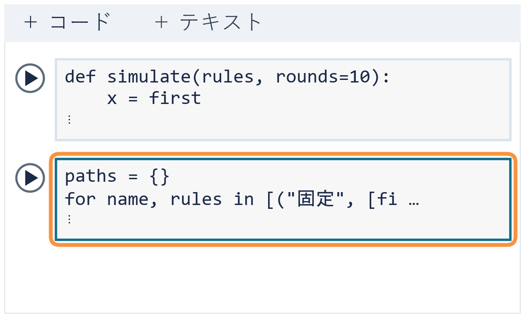

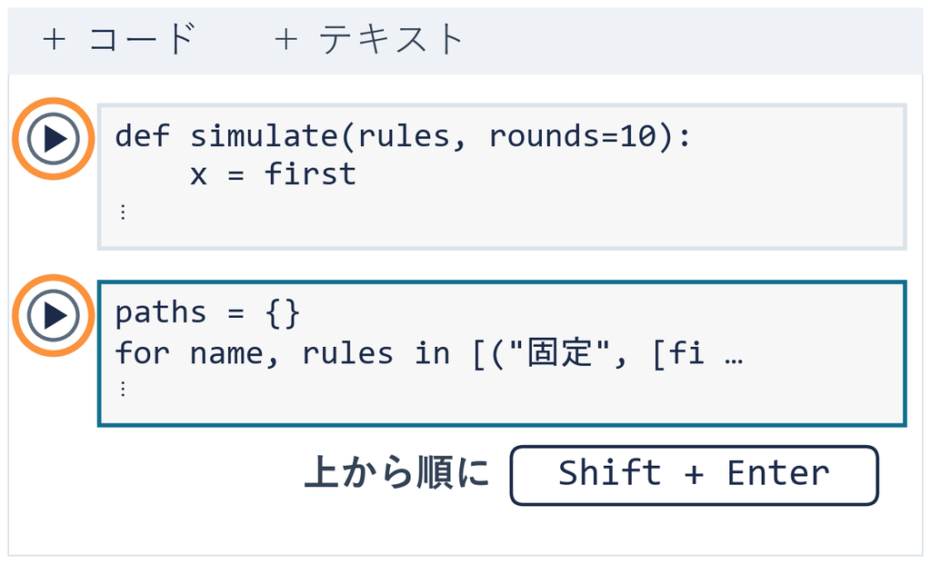

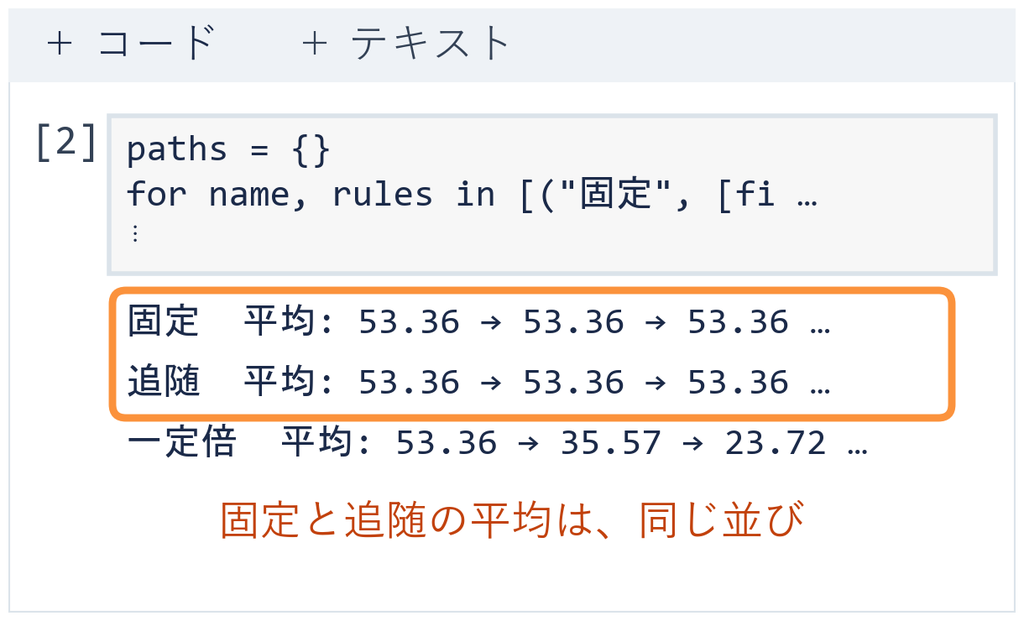

⏸ PAUSE 動画を止めて $5$ 分。3 行が出たら再生に戻る

## 3つのルールの出力の確かめ

固定 平均: 53.36 → 53.36 → 53.36 10回後: 53.36 標準偏差(1回後): 28.56  
追随 平均: 53.36 → 53.36 → 53.36 10回後: 53.36 標準偏差(1回後): 0.0  
一定倍 平均: 53.36 → 35.57 → 23.72 10回後: 0.93 標準偏差(1回後): 0.0

- **平均**：固定と追随は同じ線。一定倍だけ 0 へ
- **標準偏差**：固定は 28.56、他の2つは1回で 0

例：平均は同じでも、追随は1回で散らばりが0

## 演習 2 教室の R1 から回す3つのルール

2026年度のデータ

演習 2

1回後の平均が、教室の R2 の 34.58 になるルールは

```python
r1_all = pd.read_csv("lecture04_beauty_R1.csv")
room = r1_all["section"] == "教室"
inclass = r1_all["status"] == "授業内"
first = np.array(r1_all[room & inclass]["value"])  # 出発点＝教室の R1
n = len(first)                                     # 52人
for name, rules in [("固定", [fixed] * n), ("追随", [follow] * n),
                    ("一定倍", [multiply] * n)]:
    means, sds = simulate(rules, rounds=3)
    print(name, " 平均:", np.round(means, 2))
```

**先に考える**：ⓐ 固定 ⓑ 追随 ⓒ 一定倍 ⓓ どれでもない

⏸ PAUSE 動画を止めて $5$ 分。CSV を先にアップロード。写して実行し、2 つ目の数を 34.58 と比べる

## 演習 2 の答え：教室の4点の道筋

2026年度のデータ

答えは ⓓ。1回後に 34.58 になるルールは無い

[figure not shown]

どの1つのルールの道筋とも、教室の4点は違う

## まとめ

- **統制した比較**：出発点は共通、変えるのはルールだけ
- **平均だけでは足りない**：標準偏差も見る
- **行き先はルールしだい**：0へ向かうのは一定倍の形のせい
- **1つのルールでは足りない**：教室の4点の道筋にならない

次は、3つのルールを混ぜた40人を回す

タプル：リストと違い、中身を後から変えない組。for で1組ずつ取り出し、  
name と rules の2つに分けて受け取る

経済プログラミング特論II

第4回 — Topic03

混合モデルの集団動学

動かない人が、平均の行き先を決める

## 今日の道のり

1

ルールを書く

演習 1-1・1-2

半分と追随

2

ルールで比べる

演習 2

教室の R1 から

3

混ぜる

演習 3

固定人数と固定点

4

確かめる

演習 4

合う2組のその先

ルールを混ぜると、平均が途中で止まる

## 混ぜた40人の行き先

固定8人・追随12人・一定倍20人の40人を、30回動かす

- **①** 一定倍がいるので、平均は 0 へ向かう
- **②** 固定がいるので、平均は 53.36 のまま
- **③** 平均は途中まで下がり、どこかで止まる

動画を止めて1分。①〜③から1つ選び、理由を考える

## 固定 1 人を混ぜた 5 人の平均

まず 5 人で手で追う。いつも 60 の固定 1 人・追随 2 人・一定倍 2 人

| 回 | 固定 | 追随 2 人 | 一定倍 2 人 | 平均 | 36 との差 |
| --- | --- | --- | --- | --- | --- |
| 最初 | 60 | 30・50 | 70・60 | 54 | 18 |
| 1 | 60 | 54・54 | 36・36 | 48 | 12 |
| 2 | 60 | 48・48 | 32・32 | 44 | 8 |
| 3 | 60 | 44・44 | 29.33・29.33 | 41.33 | 5.33 |
| 4 | 60 | 41.33・41.33 | 27.56・27.56 | 39.56 | 3.56 |
| 36 なら | 60 | 36・36 | 24・24 | 36 | 0 |

36 との差は、毎回 2/3 に縮む。36 を入れると、次も 36

縮む割合 2/3 ＝ 追随の割合 2/5 ＋ 一定倍の割合 2/5 × 2/3（前の平均に掛かる数）

## 途中で平らになる平均

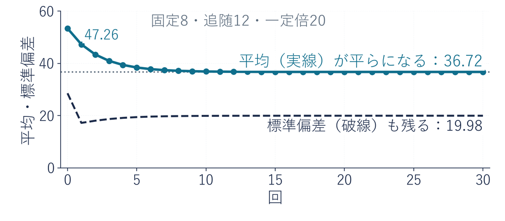

答えは③。36.72 で平らになり、散らばりも残る

## 固定点

用語

**固定点**＝次の回も同じ数が出る平均

- **混合（8・12・20）**：固定点は 36.72
- **全員一定倍**：0 へ落ちる（固定点は 0）
- **全員追随**：53.36（はじめから動かない）

36.72 という高さは、どこから決まるか

## 更新のルール

前の回の平均から次の平均を決める式（更新のルール）

$m_{t+1} = 0.2\,m_F + 0.3\,m_t + 0.5 \times \frac{2}{3}\,m_t$

$t$＝何回目かの番号（ティー）。最初が 0、1 回目が 1、2 回目が 2

$m_t$＝ $t$ 回目の 40 人の平均（エムティー）。最初は $m_0$ ＝ 53.36

$m_{t+1}$＝その次の回の平均（エムティープラスイチ）。$m_1$ ＝ 47.26

$m_F$＝固定 8 人の最初の数の平均（エムエフ）＝ 67.32。ずっと同じ

0.2＝固定 8 人の割合（8 ÷ 40）。最初の数を書き続ける

0.3＝追随 12 人の割合（12 ÷ 40）。前の平均 $m_t$ をそのまま書く

0.5＝一定倍 20 人の割合（20 ÷ 40）。前の平均の 2/3 を書く

$m_t$ に掛かる数（係数）をまとめると 0.3 ＋ 0.5 × 2/3 ≈ 0.63。1 未満

## 固定点の求め方：3つの STEP

1. **代入する**：両辺に固定点 $m_*$（エムスター）を入れる  
   → $m_* = 0.2\,m_F + 0.633\ldots\,m_*$
2. **移項する**：右辺の $m_*$ の項を左辺へ移す  
   → $(1 - 0.633\ldots)\,m_* = 0.2\,m_F$
3. **両辺を割る**：$m_*$ の係数 $0.366\ldots$ で両辺を割る  
   → $m_* = 0.2 \times 67.32 \div 0.366\ldots \approx 36.72$

式の 36.72 と、グラフの平らな所が同じ高さ

## 固定点を決める動かない人

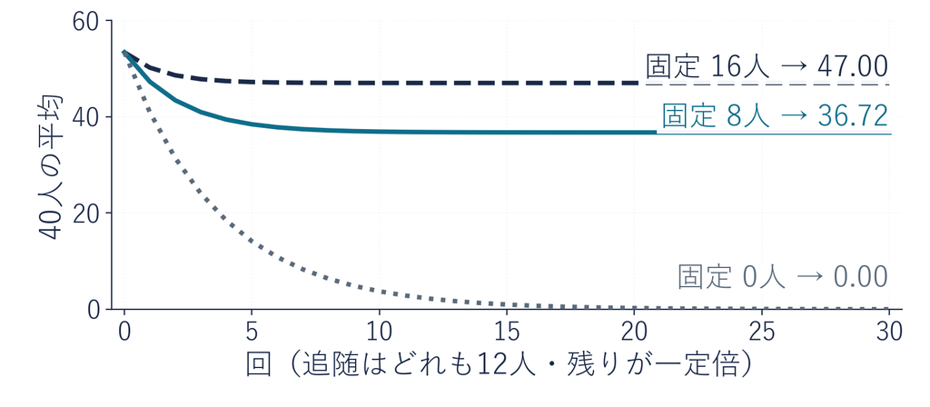

固定0人なら固定点は 0、16人なら 47.00 に上がる

## 「混ぜたから止まる」という読み違い

✕ よくある読み違い

ルールを混ぜたので  
平均は0より上で止まる

○ 図で見たこと

固定が0人の混合  
（追随12・一定倍28）は  
0 まで落ちた（固定点は 0）

0 より上で止まるのは、動かない人がいるから

## 固定点の写経

```python
first = np.random.default_rng(seed).uniform(0, 100, 40)  # 40人に戻す
k = 8                              # 固定の人数（0 や 16 に変えてみる）
rules = [fixed] * k + [follow] * 12 + [multiply] * (28 - k)
means, sds = simulate(rules, rounds=100)
react = (12 + (28 - k) * 2 / 3) / 40        # 前の平均に掛かる数（k=8 で 0.63）
floor = sum(first[:k]) / 40 / (1 - react)   # 固定点（式の値）
print("固定", k, "人  100回後の平均:", round(means[100], 2),
      " 式の値:", round(floor, 2))
```

| 行 | 部品 | 中身 |
| --- | --- | --- |
| 1 | **① 40人に戻す** | 演習 2 で教室の 52 人にしたので、40 人に戻す |
| 2 | **② 固定の人数** | k ＝ 8 人 |
| 3 | **③ 40人のルール** | 固定 k・追随 12・一定倍 28 − k の順に並べる |
| 4 | **④ 動かす** | 前に出てきた simulate で 100 回 |
| 5-6 | **⑤ 式の値** | 前の平均に掛かる数 → 固定点 |
| 7-8 | **⑥ 並べて出す** | 100回後の平均と式の値 |

`sum(first[:k]) / 40` ＝ 固定の人の最初の数の合計 ÷ 40（＝ 0.2 × $m_F$ の k 人版）・`first[:k]` ＝ 先頭の k 人

## 固定点の写経と実行

1. 段2 まで実行し  
   **＋ コード**でセルを足す
2. p.55 の 8 行を上から写す
3. **▶** か **Shift + Enter** で実行  
   （Mac は Shift + return）
4. 2 つの数が  
   同じ 36.72 かを見る

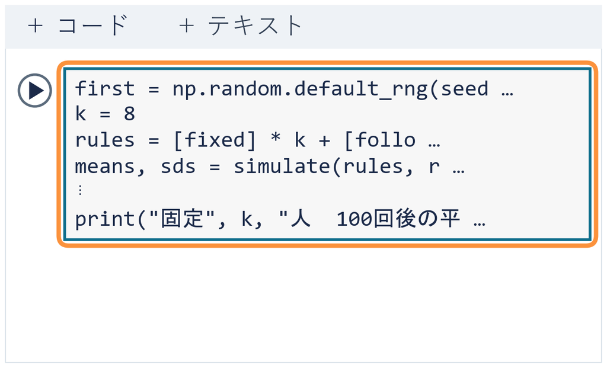

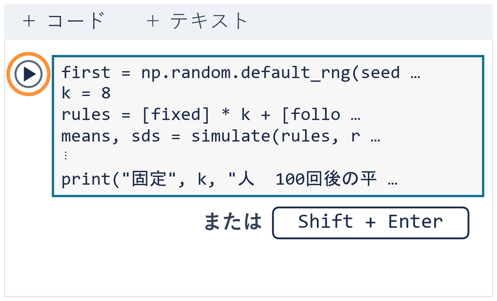

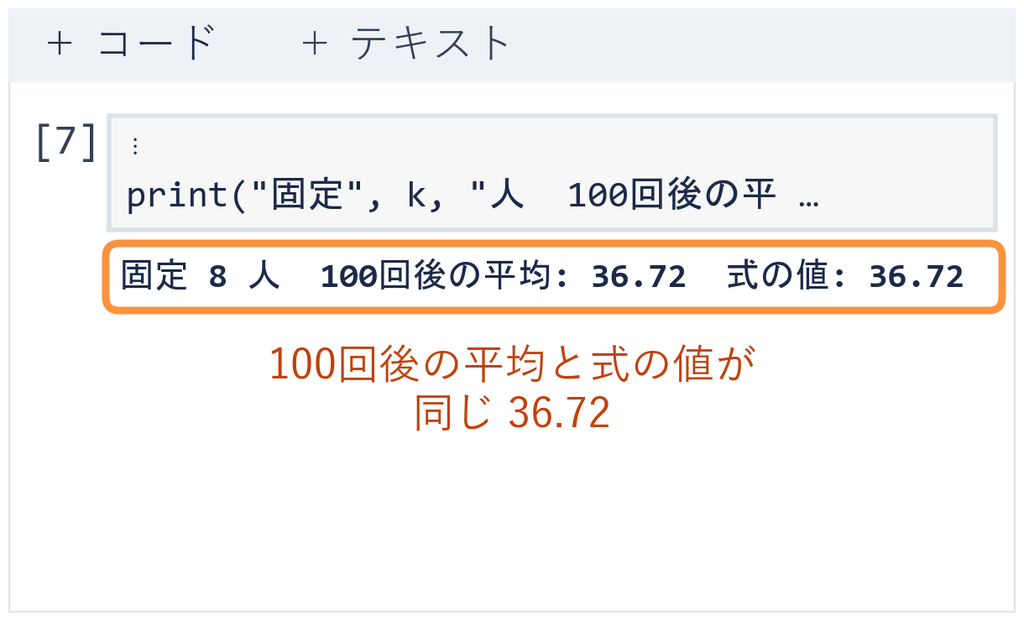

⏸ PAUSE 動画を止めて $3$ 分。2 つの数が出たら再生に戻る

## 演習 3 固定の人数と固定点

```python
first = np.random.default_rng(seed).uniform(0, 100, 40)  # 40人に戻す
k = 8                              # 固定の人数（0 や 16 に変えてみる）
rules = [fixed] * k + [follow] * 12 + [multiply] * (28 - k)
means, sds = simulate(rules, rounds=100)
react = (12 + (28 - k) * 2 / 3) / 40        # 前の平均に掛かる数（k=8 で 0.63）
floor = sum(first[:k]) / 40 / (1 - react)   # 固定点（式の値）
print("固定", k, "人  100回後の平均:", round(means[100], 2),
      " 式の値:", round(floor, 2))
```

1. **先に考える**：k ＝ 0 の式の値は ⓐ 0 ⓑ 0 より上 ⓒ 計算できない
2. **新しいセルで変える**：8 行を写し、2 行目の 8 を 0、次に 16 にして実行
3. **終わり**：3 つの k で、2 つの数を書き留めたら

⏸ PAUSE 動画を止めて $3$ 分。3 つの k の数を書き留めたら再生に戻る

## 演習 3 の答え：式とシミュレーションの一致

三択の答えは ⓐ 0。固定の人の最初の数の合計が 0 なので、式の値も 0

出力（3 つの k）

固定 8 人100回後の平均: 36.72 式の値: 36.72

固定 0 人100回後の平均: 0.0 式の値: 0.0

固定 16 人100回後の平均: 47.0 式の値: 47.0

- **固定0人**：固定点は 0。100回後の平均も式の値も 0.0
- **固定16人**：固定点が上がって 47.0

0・8・16人では、固定が多いほど固定点が高い  
固定点は、固定の人数と、その人たちの数の両方で決まる

## 公共財：1点入れたときの得の動き

4人組・持ち点20点。入れた点の合計を 1.6 倍して、4人で等分する

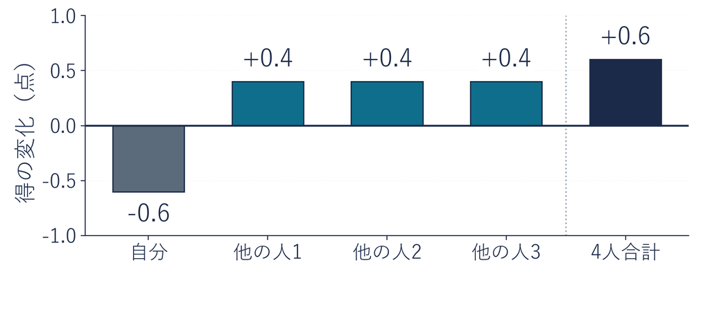

1点は 1.6 倍して4人で分ける。自分だけは損

## 同じ形で書く公共財のルール

用語

**条件付き協力**＝前回のクラス平均と同じだけ入れる

**ただ乗り**＝いつも0を入れる

- **条件付き協力**：美人投票の追随と同じ形
- **ただ乗り・いつも20**：固定と同じ形（20は持ち点を全部入れる人）
- **関数では**：return prev_mean ／ 0 ／ 20

ルールの形が同じなら、動きも同じ型

## 公共財の 4 人組の平均拠出

4 人組で手で追う。いつも20・ただ乗り・条件付き協力 2 人

| 回 | いつも20 | ただ乗り | 条件付き 協力 2 人 | 平均 |
| --- | --- | --- | --- | --- |
| 最初 | 20 | 0 | 16・20 | 14 |
| 1 | 20 | 0 | 14・14 | 12 |
| 2 | 20 | 0 | 12・12 | 11 |
| 3 | 20 | 0 | 11・11 | 10.5 |
| 4 | 20 | 0 | 10.5・10.5 | 10.25 |
| 10 なら | 20 | 0 | 10・10 | 10 |

いつも20 の 1 人がいると、固定点は 10  
その人も条件付き協力なら 14 → 10.5 → 7.88 → 5.91 と 0 へ

## 仮定したルールで回すと（人工集団）

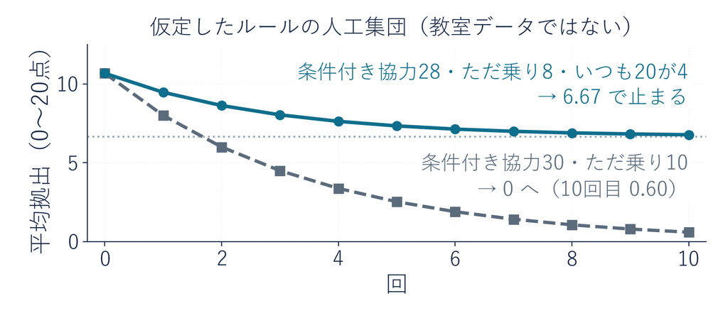

いつも20が1割いると 6.67 で止まる

## 2つのゲームの同じ形

| 集団（人数） | 前の平均に 掛かる数 | 動かない人 | 固定点 |
| --- | --- | --- | --- |
| 美人投票（固定8・追随12・一定倍20） | 0.63 | 固定8人 | 36.72 |
| 美人投票（固定0・追随12・一定倍28） | 0.77 | いない | 0 |
| 公共財（協力30・ただ乗り10） | 0.75 | 0の人だけ | 0 |
| 公共財（協力28・ただ乗り8・20が4） | 0.70 | 20の4人 | 6.67 |

募金や町内会費も、同じ形で行き先が決まる

美人投票の 0.63 ＝ 0.3 ＋ 0.5 × 2/3（人の割合ではない）  
公共財は協力する人の割合と同じ数になる

## まとめ

- **混ぜた集団**：0 より上の数を書き続ける人がいれば  
  平均は 0 より上の固定点で平らになる
- **更新のルール**：掛かる数が1未満なら差が縮む
- **固定点を決めるのは動かない人**：公共財ではいつも20の人

次は、このモデルを教室の数に合わせたとき、何が言えるか

経済プログラミング特論II

第4回 — Topic04

キャリブレーションと  
妥当性検証

合っても、正しいとは限らない

## 今日の道のり

1

ルールを書く

演習 1-1・1-2

半分と追随

2

ルールで比べる

演習 2

教室の R1 から

3

混ぜる

演習 3

固定人数と固定点

4

確かめる

演習 4

合う2組のその先

合うことと、正しいことは別

## 平均の一致から分かること

2026年度のデータ

教室の R1 の52人を1回動かしたら、教室の R2 の平均 34.58 と  
小数第1位まで合う人数比（固定・追随・一定倍）が見つかった

- **①** 教室の人の考え方が分かった
- **②** 半分くらい分かった
- **③** 平均だけでは、まだ分からない

手がかり：前に出てきた「同じ22でも、理由は1つでない」

動画を止めて1分。①〜③から1つ選んだら再生に戻る

## 3 人の人数比と 1 回後の平均

3 人 40・20・30（平均 30）：固定＝自分の数、追随＝30、一定倍＝30 × 2/3 ＝ 20  
固定は先頭の人から。次のラウンドの平均が 26.67 だったとして、合う組を 1 行ずつ探す

[figure not shown]

**26.67 に合う組は 3 つ。平均は同じでも、標準偏差は 4.71 と 9.43**

## 合わせる相手：教室の R2

2026年度のデータ

今度は教室の数。R1 の52人から出発し、R2 の平均 34.58 に合わせる

- **合わせる数**：1回後の平均。小数第1位まで同じ（34.6）なら合う
- **動かすもの**：固定・追随・一定倍の人数（合計52）。  
  固定は回答の早い順に先頭から
- **出発点が教室の理由**：計算機の40人からは、  
  1回後の平均が 35.57 より下がらない

52人を3つのルールに分ける分け方は 1,431 通り  
1組ずつ計算して探す

## 複数ある合う人数比

2026年度のデータ

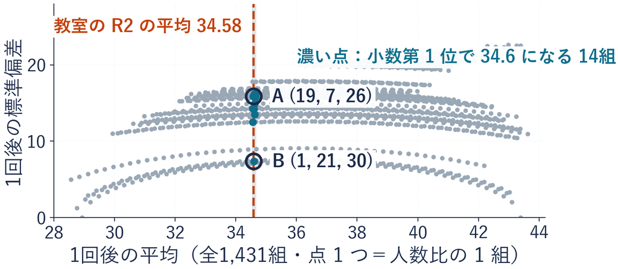

合う組は14組。標準偏差は 7.34〜16.17

## ほぼ同じ平均とまるで違う中身

2026年度のデータ

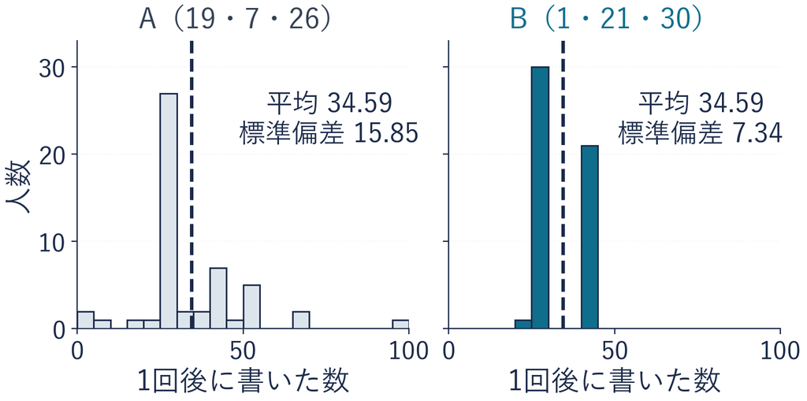

平均はどちらも 34.59。標準偏差は 15.85 と 7.34

## 「考え方が分かった」という読み違い

✕ よくある読み違い

平均がぴったり合った  
だから教室の人は、  
このルールで考えていた

○ 図で見たこと

A でも B でも平均は合う  
合ったのは平均だけで、  
まだ何も確かめていない

合うように選んだのだから、合うのは当たり前

## キャリブレーションと妥当性検証

用語

**キャリブレーション**＝結果に合わせて決める（当てはめ）

**妥当性検証**＝別の条件・データで確かめる

- **合わせた数**：平均。選んだので証拠にならない
- **確かめる数**：合わせに使っていない数（例：標準偏差）
- **確かめる相手**：次のラウンドのデータ（予測と比べる）

売上予測も、今年当たるかは別に確かめる

## キャリブレーションの手順

1. **前提を置く**：出発点の数と 3 つのルールの式は変えない  
   → 3 人は 40・20・30、教室は R1 の 52 人
2. **動かす数を決める**：3 つのルールの人数（合計は変えない）  
   → 3 人は 10 通り、教室は 1,431 通り
3. **目標の数を決める**：合わせる相手のデータの値  
   → 3 人は 26.67、教室は R2 の平均 34.58
4. **全部の組を計算して判定する**：表示の桁で目標と同じ組を残す  
   → 3 人は 3 組、教室は小数第 1 位（34.6）で 14 組

残った組を、目標に使っていない数で確かめる＝妥当性検証

## A と B の写経

2026年度のデータ

```python
r1_all = pd.read_csv("lecture04_beauty_R1.csv")
room = r1_all["section"] == "教室"
inclass = r1_all["status"] == "授業内"
first = r1_all[room & inclass]["value"].to_numpy()
for f, fo, mu in [(19, 7, 26), (1, 21, 30)]:
    rules = [fixed] * f + [follow] * fo + [multiply] * mu
    means, sds = simulate(rules, rounds=1)
    print((f, fo, mu), "1回後の平均:", round(means[1], 2),
          " 標準偏差:", round(sds[1], 2))
```

| 行 | 部品 | 渡すもの | 返ってくるもの |
| --- | --- | --- | --- |
| 1-4 | **① 出発点を教室に** | CSV と 2 つの条件 | 52 人の数の並び `first` |
| 5-6 | **② 組ごとのルール** | 3 つの人数 f・fo・mu | 52 人ぶんの `rules` |
| 7 | **③ 1 回動かす** | `rules` と `rounds=1` | 平均と標準偏差の並び |
| 8-9 | **④ 1 回後を見る** | `means[1]`・`sds[1]` | 2 つの数 |

## A と B の写経と実行

1. **＋ コード**で空の  
   セルを足す
2. p.75 の 9 行を上から写す
3. **▶** か **Shift + Enter** で実行  
   （Mac は Shift + return）
4. 2 行とも 34.59 で、  
   標準偏差が違うのを見る

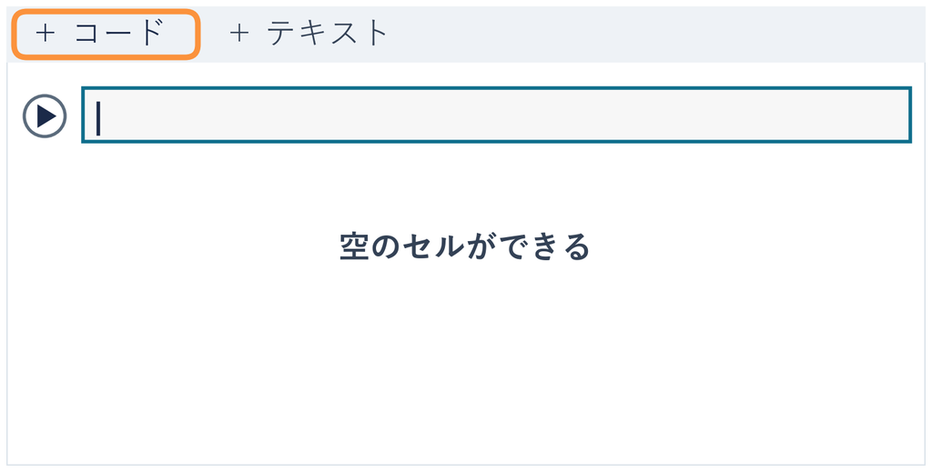

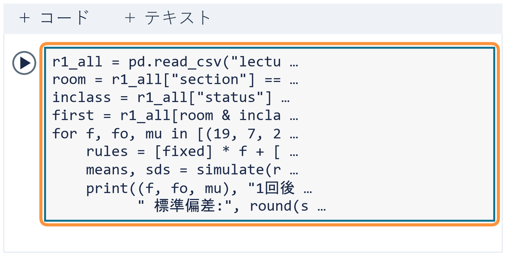

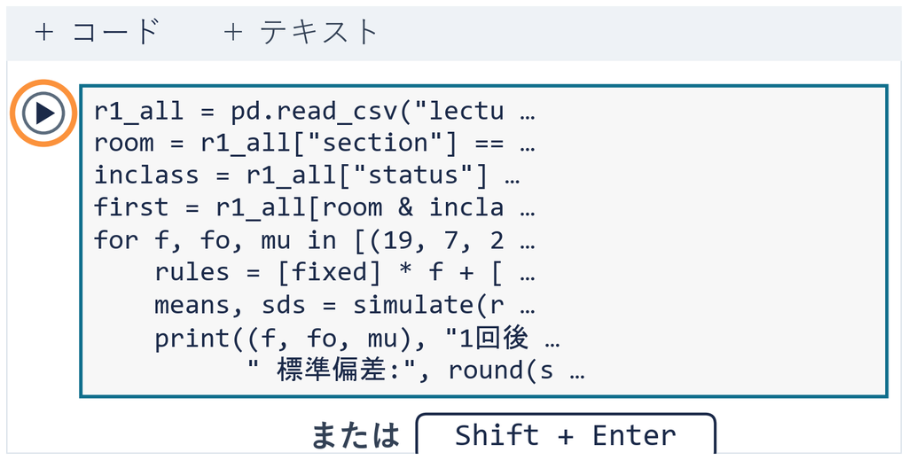

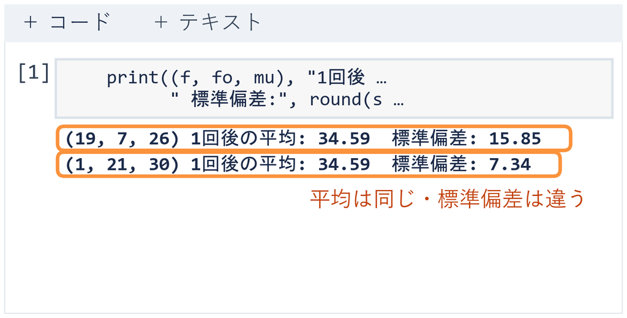

⏸ PAUSE 動画を止めて $3$ 分。2 行が出たら再生に戻る

## A と B の出力の読み方

2026年度のデータ

出力（A と B）

(19, 7, 26) 1回後の平均: 34.59 標準偏差: 15.85  
(1, 21, 30) 1回後の平均: 34.59 標準偏差: 7.34

- **平均**：どちらも 34.59。小数第1位で 34.6 ＝ 教室の 34.58 と合う
- **標準偏差**：15.85 と 7.34。同じ平均でも、散らばりは違う

自分の画面の 2 行が同じなら、前のページの図と同じ計算ができている

## デモ：教室の R1 から合わせる

数の話

同じ集団（40人か、教室の R1 の52人）から出発し、  
ルールの組だけを変えて1回ずつ同時に更新する

- **何を見るか**：▶ を押すたびに、平均と散らばりがどう動くか
- **図の意味**：左＝今の集団のヒストグラム／右＝回ごとの平均と標準偏差  
  （教室のときは R2 の平均 34.58 の点線）
- **操作**：タブでルールの組を選ぶ・スライダで人数を決める・▶ で1回

ミッション 下の段（教室の R1 から）で、  
A・B のほかに1回後の平均が 34.6 になる組を1つ探す

※ 次のスライドへ進むときは、デモの枠の外を一度クリックしてから ← → キーを押す

[interactive chart not shown]

## 3 人の組の 2 回後の平均

2026年度のデータ

デモの答えの例：固定 10・追随 13・一定倍 29 → 1回後の平均 34.59（標準偏差 14.19）

3 人に戻る。26.67 に合った 3 組を、同じルールのまま次のラウンドへ

[figure not shown]

**1 回後は同じ 26.67。2 回後で 23.70・25.19・25.93 に分かれる**

## 合わせた数と確かめた数

2026年度のデータ

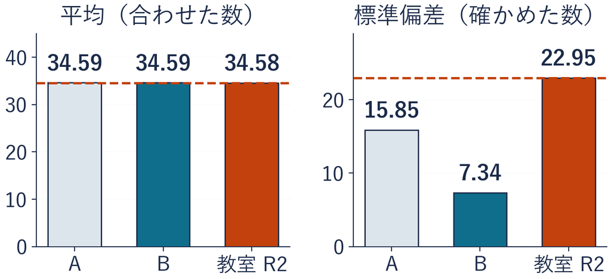

確かめた数（教室の R2 の標準偏差 22.95）には、A も B も届かない  
合う14組でも最大 16.17。平均だけ合わせても、中身は当たらない

## 教室の 4 点と A・B の道筋

2026年度のデータ

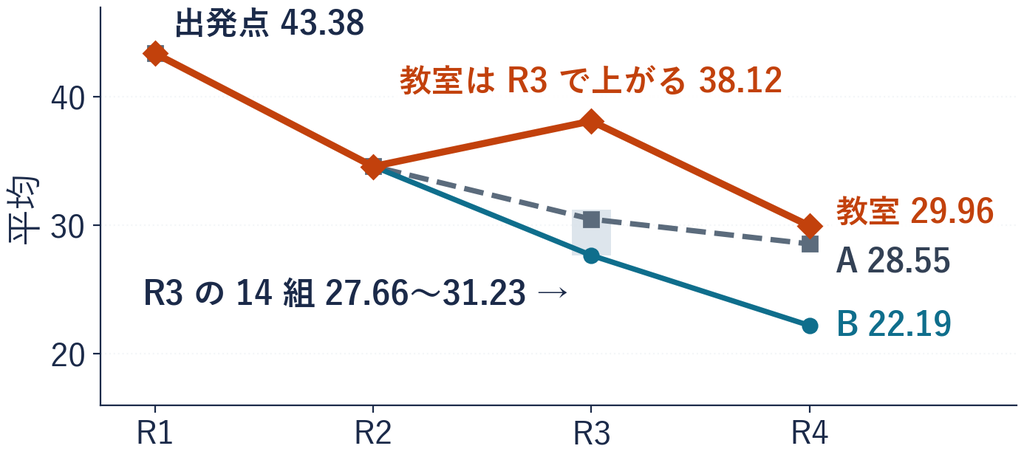

14組はどれも R3 で下がる（27.66〜31.23）。教室は 38.12 に上がった  
3つのルールの組では、教室の上がり方を作れない

## R3・R4 の位置の写経

2026年度のデータ

```python
class_mean = [43.38, 34.58, 38.12, 29.96]   # 教室の R1〜R4 の平均
for f, fo, mu in [(19, 7, 26), (1, 21, 30)]:
    rules = [fixed] * f + [follow] * fo + [multiply] * mu
    means, sds = simulate(rules, rounds=3)
    print((f, fo, mu), "R3:", round(means[2], 2), "R4:", round(means[3], 2))
    print("  教室との差", round(class_mean[2] - means[2], 2),
          round(class_mean[3] - means[3], 2))
```

| 行 | 部品 | 渡すもの | 返ってくるもの |
| --- | --- | --- | --- |
| 1 | **① 教室の 4 つの平均** | 教室で映した平均 | 4 つの数の並び |
| 2-4 | **② 3 回動かす** | `rounds=3` | 1・2・3 回後＝R2・R3・R4 |
| 5 | **③ R3・R4 の位置** | `means[2]`・`means[3]` | 2 つの数 |
| 6-7 | **④ 教室との差** | 教室 − モデル | ＋なら教室が高い |

`first` は前の写経で教室の R1 にしたまま。2〜4 行目は前の写経と同じ形で、`rounds` だけ 3 に